# Exploratory Data Analysis: Big Five Personality Traits

# Personality Clustering, Modeling, and Analysis

**Julian Benitez Mages & Anaelle Surprise**

[figure not shown]

## Project Overview

This project investigates personality structure through unsupervised and supervised learning. Using over 1 million responses to the IPIP-NEO 50-item Big Five Personality survey, we explore whether distinct personality clusters emerge, and whether traits can predict geographic region.

## Setup Instructions

1. Clone this repository and install required dependencies:

```bash
git clone <your-repo>
cd <your-repo>
pip install -r requirements.txt
```

2. Preprocess the dataset:

```bash
python preprocess_data.py
```

This script loads and cleans the IPIP dataset, computes Big Five scores, filters to one response per user, and outputs a clean CSV file for modeling.

## Background: The Big Five Traits

The Big Five Factor Model describes personality in terms of five traits: - **Openness** (to experience) - **Conscientiousness** - **Extraversion** - **Agreeableness** - **Neuroticism**

Our dataset contains responses to 50 items, with accompanying metadata like time spent, country, and screen size. These traits are computed as aggregate scores based on question groups.

## Background & Context

The **Big Five Personality Traits** (also known as the **Five Factor Model**) is a framework for understanding personality based on five traits: - Openness - Conscientiousness - Extraversion - Agreeableness - Neuroticism

The **IPIP** inventory measures these traits through a set of 50 questions, each rated from 1 to 5. This dataset includes over 1 million responses, collected globally between 2016–2018, with metadata such as country, screen size, and time spent per survey page.

## Trait Distributions

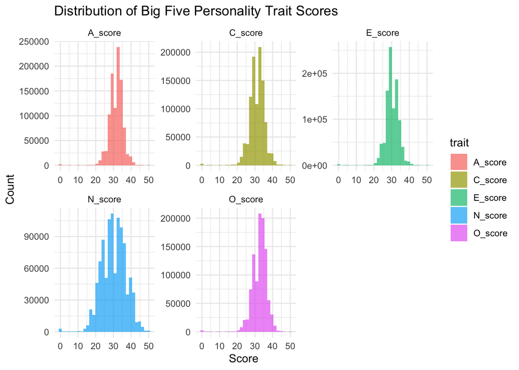

## Correlation Analysis

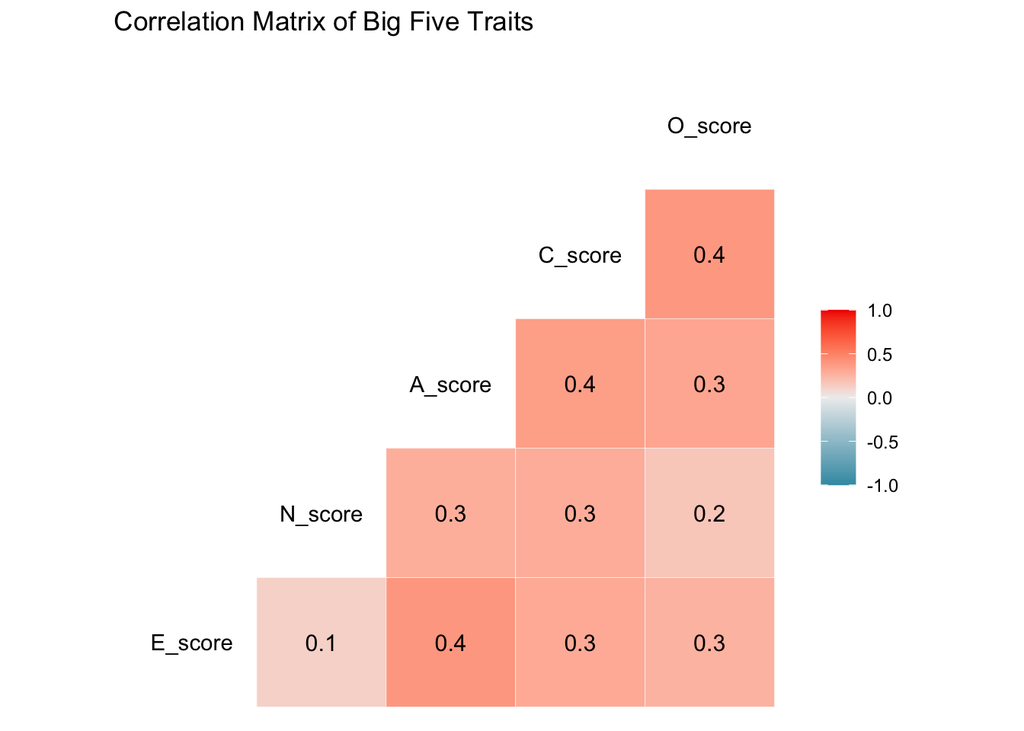

## Geographic Distribution

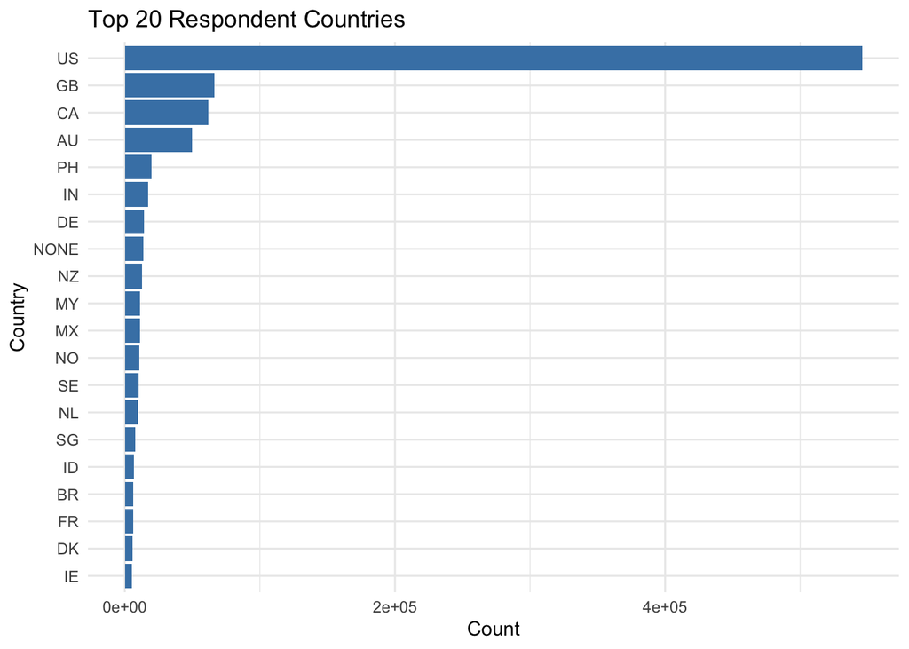

## Dimensionality Reduction (PCA)

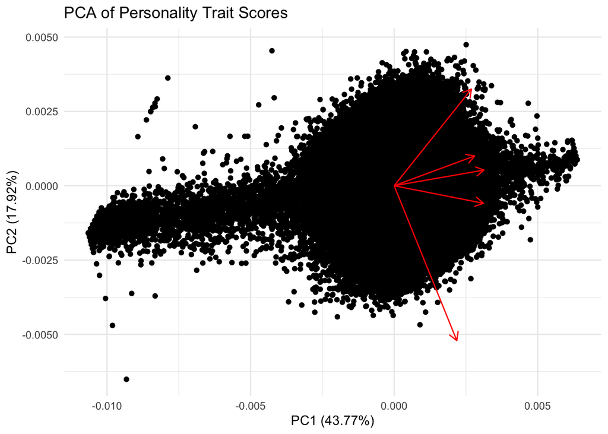

```
## # A tibble: 18 × 7
##    sub_region                      avg_E avg_N avg_A avg_C avg_O      n
##    <chr>                           <dbl> <dbl> <dbl> <dbl> <dbl>  <int>
##  1 Northern America                 30.3  30.0  31.6  31.4  32.8 607810
##  2 Northern Europe                  30.0  30.6  31.2  30.8  32.9 106663
##  3 Australia and New Zealand        30.3  30.1  31.6  30.9  32.5  62741
##  4 South-eastern Asia               30.6  31.5  32.6  31.3  31.4  50409
##  5 Western Europe                   29.8  29.9  31.1  31.0  33.2  39380
##  6 Latin America and the Caribbean  30.1  31.4  31.5  31.8  33.0  35951
##  7 Southern Asia                    30.6  30.7  32.6  30.6  31.2  23231
##  8 Southern Europe                  29.9  30.8  31.1  31.2  32.8  22425
##  9 Eastern Europe                   29.7  31.1  31.1  31.1  32.8  18658
## 10 <NA>                             30.2  30.5  31.7  31.0  32.4  14649
## 11 Western Asia                     30.0  31.1  31.8  31.0  32.2  12070
## 12 Eastern Asia                     29.8  30.2  31.5  30.4  31.3   8826
## 13 Sub-Saharan Africa               30.2  29.6  31.5  31.0  32.9   7771
## 14 Northern Africa                  29.9  31.9  31.7  30.6  32.2   2087
## 15 Central Asia                     29.8  30.9  31.6  30.8  31.6    617
## 16 Micronesia                       30.6  30.6  32.1  31.4  32.3    134
## 17 Melanesia                        30.8  29.2  32.5  30.5  32.6     93
## 18 Polynesia                        31.4  32.6  34.2  32.6  32.6     43
```

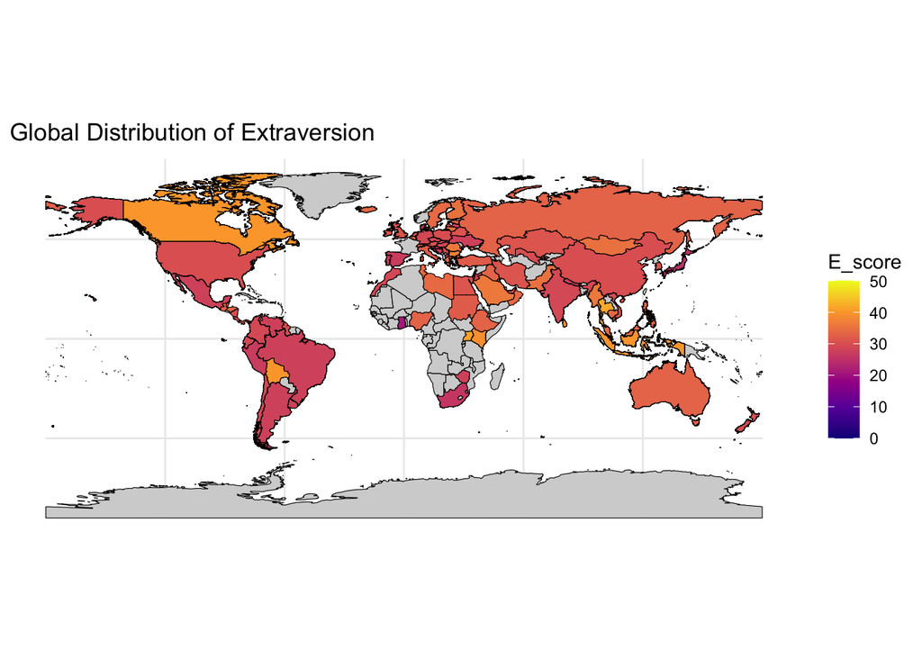

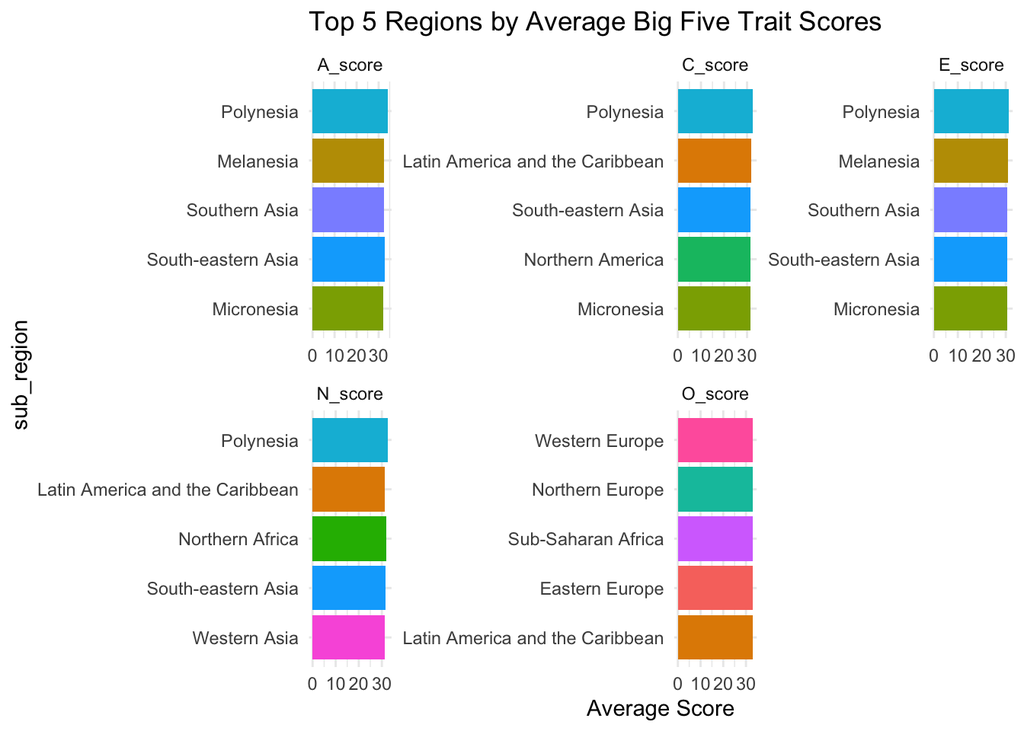

## Clustering

Using `clusering_v2.py`, we applied KMeans, GMM, and DBSCAN on scaled survey data and calculated silhouette and Davies-Bouldin scores. Best models were saved, and labeled cluster data exported to JSON for D3 dashboard integration.

## Predictive Modeling: U.S. Region

In `PredictiveModel.py`, a Random Forest predicts U.S. region (Northeast, Midwest, South, West) based on personality traits. Coordinates were mapped to regions, data undersampled for balance, and performance evaluated using accuracy and classification reports.

## Cluster Classification

`cluster_prediction_v2.py` trains classifiers (Random Forest, Logistic Regression, SVM, MLP) to predict a user’s cluster based on their raw answers. We also evaluate feature importance and visualize model accuracy.

## D3.js Interactive Dashboard

The dashboard allows users to: - Select a personality trait - Choose a clustering method (KMeans or GMM) - View a stacked histogram of trait distributions across clusters

It is built with D3 and styled via custom CSS. Load it by running:

```bash
cd dashboard
python -m http.server
```

## References

- IPIP Dataset: https://openpsychometrics.org
- Goldberg, L. R. (1992). The development of markers for the Big-Five factor structure.